# 使用 R 擷取中央氣象局資料

2016-10-03

最近因為工作需要，老闆好奇天氣資料與門店人流或銷售數字的關聯性，看了中央氣象局的[資料申購方法](http://e-service.cwb.gov.tw/wdps/cwb_fee.htm)，為了做個簡單的POC就得花錢買詳細的氣象資料，似乎太大張旗鼓了。還好，氣象局的[觀測資料查詢系統](http://e-service.cwb.gov.tw/HistoryDataQuery/index.jsp)可以提供手動查詢部分氣象站的資訊，觀察網頁的URL，只要進行日期的替換就可以做特定時間的查詢，而且產出的頁面也是整齊的表格，正好可以測試使用R爬取網頁資料的程序。

先做一次性的測試:

```r
# 先設定好站點編號
stationID <- '466930'

#----------------------------------------------#
# 撈取日報(逐小時的紀錄)
# 先設定好欄位名稱，撈取日期
tbNames <- c('ObsTime','StnPres','SeaPres','Temperature','TdDewPoint','RH','WS','WD','WSGust','WDGust','Precp','PrecpHour','SunShine','GloblRad','Visb')
fdate <- '2016-09-01'

cwbURL <- sprintf('http://e-service.cwb.gov.tw/HistoryDataQuery/DayDataController.do?command=viewMain&station=%s&stname=%s&datepicker=%s', stationID, '%25E8%2587%25BA%25E5%258C%2597', fdate)
weatherDate <- cwbURL %>%
  getURL() %>%
  htmlParse(., encoding = 'utf8', asText = TRUE) %>%
  readHTMLTable(header = TRUE) %$%
  MyTable %>%
  tbl_dt()

weatherDate %<>% filter(row.names(weatherDate) != 1)
weatherDate %<>% mutate_each(funs(as.numeric(as.character(.)))) %>% arrange(V1)
names(weatherDate) <- tbNames
weatherDate %<>% mutate(station = '竹子湖', cdate = fdate, ctime = (as.POSIXct(fdate)+hours(ObsTime-1)))

#----------------------------------------------#
# 撈取月報(逐日的紀錄)
# 先設定好欄位名稱，撈取日期
tbNames <- c('ObsTime','StnPres','SeaPres','StnPresMax','StnPresMaxTime','StnPresMin','StnPresMinTime','Temperature','TMax','TMaxTime','TMin','TMinTime','TdDewPoint','RH','RHMin','RHMinTime','WS','WD','WSGust','WDGust','WGustTime','Precp','PrecpHour','PrecpMax10','PrecpMax10Time','PrecpHrMax','PrecpHrMaxTime','SunShine','SunShineRate','GloblRad','VisbMean','EvapA')
fmonth <- '2016-09'

cwbURL <- sprintf('http://e-service.cwb.gov.tw/HistoryDataQuery/MonthDataController.do?command=viewMain&station=%s&stname=%s&datepicker=%s', stationID, '%25E7%25AB%25B9%25E5%25AD%2590%25E6%25B9%2596', fmonth)
weatherMonth <- cwbURL %>%
  getURL() %>%
  htmlParse(., encoding = 'utf8', asText = TRUE) %>%
  readHTMLTable(header = TRUE) %$%
  MyTable %>%
  tbl_dt()

weatherMonth %<>% filter(row.names(weatherMonth) != 1)
weatherMonth %<>% mutate_each(funs(as.numeric(as.character(.)))) %>% arrange(V1)
names(weatherMonth) <- tbNames
weatherMonth %<>% mutate(station = '竹子湖', cdate = as.Date(str_c(fmonth, ObsTime, sep = '-')))
```

確認結果表都有抓到:

```r
# 日報(逐小時的紀錄)
weatherDate %>% head() %>% select(c(1:10)) %>% knitr::kable()
```

| ObsTime | StnPres | SeaPres | Temperature | TdDewPoint | RH | WS | WD | WSGust | WDGust |
| --- | --- | --- | --- | --- | --- | --- | --- | --- | --- |
| 1 | 938.6 | 1007.0 | 22.0 | 17.8 | 77 | 0.6 | 10 | 2.7 | 30 |
| 2 | 938.1 | 1006.6 | 21.3 | 18.0 | 81 | 0.7 | 360 | 2.2 | 350 |
| 3 | 937.7 | 1005.9 | 22.4 | 16.7 | 70 | 1.5 | 340 | 4.3 | 300 |
| 4 | 937.6 | 1005.8 | 22.4 | 16.5 | 69 | 0.9 | 320 | 6.7 | 300 |
| 5 | 937.7 | 1005.9 | 22.2 | 17.1 | 73 | 0.8 | 340 | 5.5 | 320 |
| 6 | 937.7 | 1006.1 | 21.6 | 17.6 | 78 | 0.5 | 330 | 4.4 | 290 |

```r
# 月報(逐日的紀錄)
weatherMonth %>% head() %>% select(c(1:10)) %>% knitr::kable()
```

| ObsTime | StnPres | SeaPres | StnPresMax | StnPresMaxTime | StnPresMin | StnPresMinTime | Temperature | TMax | TMaxTime |
| --- | --- | --- | --- | --- | --- | --- | --- | --- | --- |
| 1 | 937.6 | 1005.3 | 939.1 | NA | 935.8 | NA | 24.4 | 29.0 | NA |
| 2 | 936.9 | 1004.7 | 937.8 | NA | 935.7 | NA | 23.5 | 29.2 | NA |
| 3 | 937.9 | 1005.8 | 939.3 | NA | 936.4 | NA | 23.7 | 27.1 | NA |
| 4 | 939.4 | 1007.1 | 940.8 | NA | 938.1 | NA | 24.9 | 28.3 | NA |
| 5 | 940.0 | 1008.0 | 941.3 | NA | 938.3 | NA | 24.2 | 25.9 | NA |
| 6 | 940.8 | 1009.0 | 942.3 | NA | 939.9 | NA | 23.4 | 26.9 | NA |

確認上述的程式可以抓到所要查詢氣象觀測站點的資料，因為格式相當固定，所以在HTML的整理上不會耗費太多精力，就是把table物件擷取出來即可。可惜後來專案變化，不需要再進行原本的分析，想想程式已經起頭了，就來收個尾吧。

剛好九月底的梅姬颱風讓大家罕見地放了兩天假，也一併解決了教師節(9/28)是否放假的爭議，好奇心地驅使下，設定了三個不同的站點，想來看看當時的天氣到底有多惡劣。我取了板橋、竹子湖、高雄這三個站點的觀測紀錄，時間範圍限定在2016-09。

> - **板橋**：生活範圍，北區
> - **竹子湖**：半山腰，北區
> - **高雄**：海港邊，南區

先進行逐日數據的比較，主要以降水量、風速，以及自製的_降水強度_做比較。降水強度是為了消除下雨時數對雨量判斷的影響。

從莫蘭蒂颱風來看，當時高雄在降雨與風速上都比北區來的高，反映在當時颱風對南部區域的破壞較大，而且整個北部區域都還是正常上班上課。不過梅姬颱風就對南北區域都造成影響，風速不論是板橋or高雄都破表，雖然降雨的部分並未像莫蘭蒂那麼強，但是單單考量風速對通勤造成的危險性，全台灣幾乎各縣市都停止上班上課。

另外有特別的是，竹子湖可能是因處在陽明山山坳的地區，所以颱風當時雖然雨勢驚人，但是風速反而是板橋、高雄這類平地/海港邊的區域較大，所以山區防雨、平地防風!?

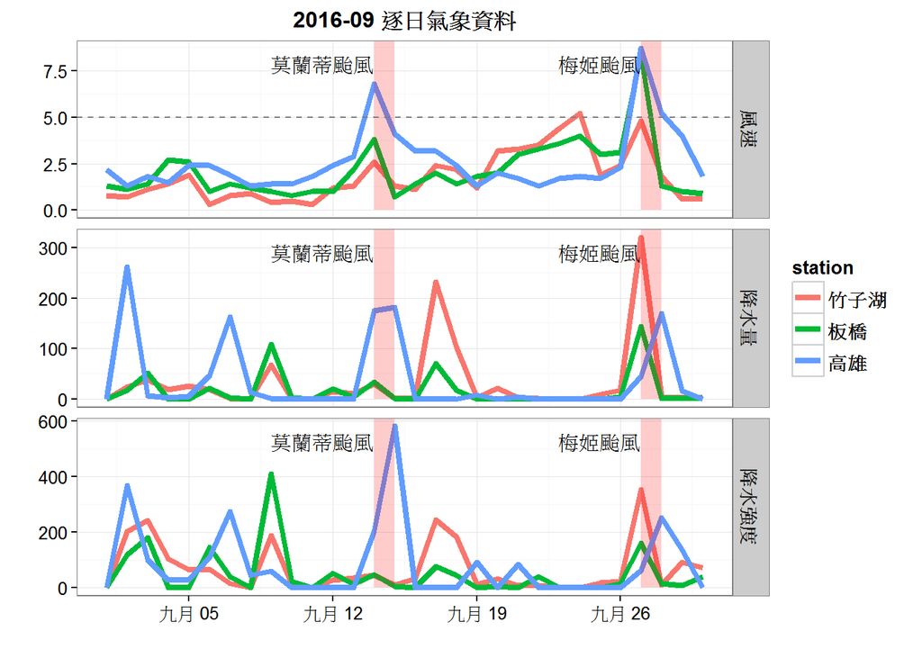

```r
weatherMonth2 <- read.csv('d:/weatherMonth2.txt', fileEncoding = 'UTF-8', sep = ',', header = TRUE, stringsAsFactors = FALSE) %>% tbl_dt()

weatherMonth2 %>% select(station, cdate, WS, Precp, PrecpHour) %>%
  mutate(RainStrength = Precp/(PrecpHour/24)) %>%
  select(-PrecpHour) %>%
  gather(key = 'vType', value = 'value', -c(1,2)) %>%
  mutate(value = ifelse(is.na(value), 0, value), cdate = as.Date(cdate)) %>% {

    flabels <- c('Precp' = '降水量', 'RainStrength' = '降水強度', 'WS' = '風速')

    ggplot(data = ., aes(x = cdate, y = value, group = station, colour = station)) +
    geom_line(size = 1.5) +
    labs(x = '', y = '', title = '2016-09 逐日氣象資料') +
    facet_grid(vType~., scales = 'free_y', labeller = as_labeller(flabels)) +
    theme_bw() +
    theme(strip.text = element_text(size = 10, face = 'bold'),
          title = element_text(size = 10, face = 'bold'),
          legend.text = element_text(size = 10, face = 'bold')) +
    annotate("rect", xmin=as.Date('2016-09-14'), xmax=as.Date('2016-09-15'), ymin=0, ymax=Inf, alpha=0.2, fill="red") +
    annotate("rect", xmin=as.Date('2016-09-27'), xmax=as.Date('2016-09-28'), ymin=0, ymax=Inf, alpha=0.2, fill="red") +
    annotate('text', label = '莫蘭蒂颱風', x = as.Date('2016-09-14'), y = Inf, vjust = 2, hjust = 1) +
    annotate('text', label = '梅姬颱風', x = as.Date('2016-09-27'), y = Inf, vjust = 2, hjust = 1) +
    geom_hline(data = data.frame(vType = 'WS'), aes(yintercept = 5), linetype = 2, colour = 'grey50')
  }
```

印象中梅姬颱風當時板橋風相當地大，待在公寓大樓甚至會有搖晃的錯覺，所以好奇心驅使下，將9/26~9/29這四天的逐小時紀錄撈出來觀察。

不過從9/28開始，風速就有明顯地下降，雨量除了高雄依然有間歇雨勢，也算是緩和下來了，雖然有人會質疑多放一天假的決定，但是對於家裡遭受梅姬颱風破壞的人來說，這一天的假就是用來恢復家園，而不是跟其他幸運兒一樣，可以跑去塞爆電影院、KTV、百貨公司。

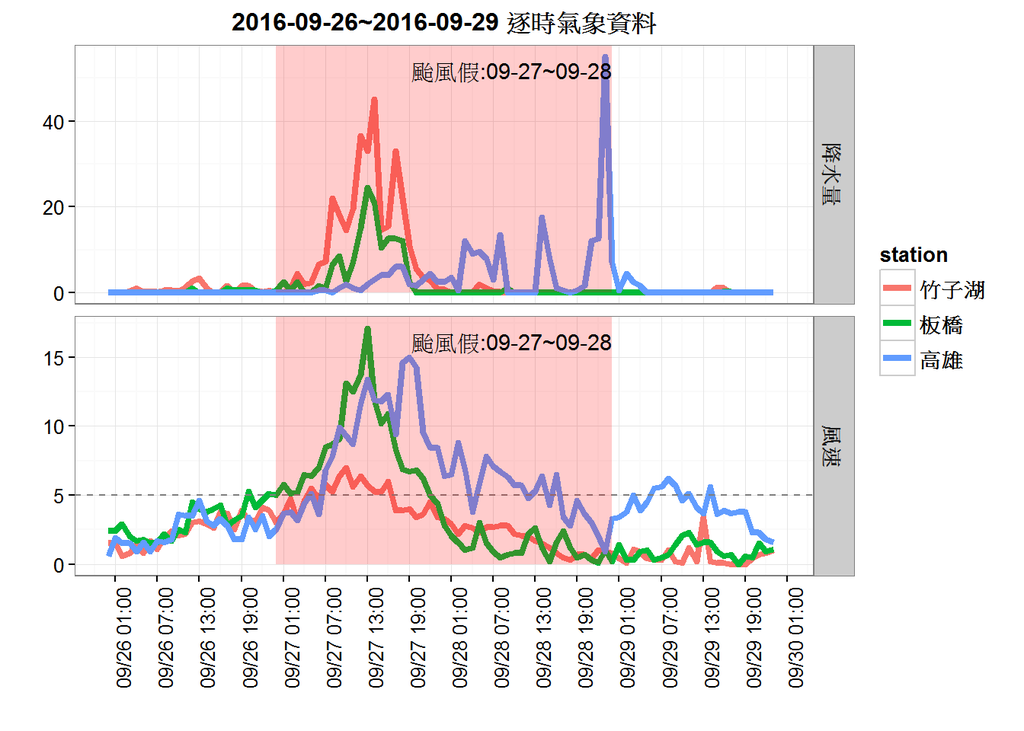

```r
weatherDate3 <- read.csv('d:/weatherDate3.txt', fileEncoding = 'UTF-8', sep = ',', header = TRUE, stringsAsFactors = FALSE) %>% tbl_dt()

weatherDate3 %>%
  filter(cdate >= as.Date('2016-09-26') & cdate <= as.Date('2016-09-29')) %>%
  select(station, ctime, Precp, WS) %>%
  gather(key = 'vType', value = 'value', -c(1,2)) %>%
  mutate(value = ifelse(is.na(value), 0, value), ctime = as.POSIXct(strptime(ctime, format = '%Y-%m-%d %H:%M:%S'))) %>%
  arrange(station, vType, ctime) %>% {

    flabels <- c('Precp' = '降水量', 'WS' = '風速')
    lim <- as.POSIXct(c(strptime('2016-09-26 00:00:00', format = '%Y-%m-%d %H:%M:%S'), strptime('2016-09-30 00:00:00', format = '%Y-%m-%d %H:%M:%S')))

    ggplot(data = ., aes(x = ctime, y = value, group = station, colour = station)) +
      geom_line(size = 1.5) +
      labs(x = '', y = '', title = '2016-09-26~2016-09-29 逐時氣象資料') +
      facet_grid(vType~., scales = 'free_y', labeller = as_labeller(flabels)) +
      theme_bw() +
      theme(strip.text = element_text(size = 10, face = 'bold'),
            title = element_text(size = 10, face = 'bold'),
            legend.text = element_text(size = 10, face = 'bold'),
            axis.text.x = element_text(angle = 90)) +
      geom_hline(data = data.frame(vType = 'WS'), aes(yintercept = 5), linetype = 2, colour = 'grey50') +
      annotate("rect", xmin = as.POSIXct(strptime('2016-09-27', format = '%Y-%m-%d')), xmax = as.POSIXct(strptime('2016-09-29', format = '%Y-%m-%d')), ymin=0, ymax=Inf, alpha=0.2, fill="red") +
      scale_x_datetime(limits = lim, breaks = date_breaks("6 hour"), labels = date_format("%m/%d %H:%M", tz = 'Asia/Taipei')) +
      annotate('text', label = '颱風假:09-27~09-28', x = as.POSIXct(strptime('2016-09-29', format = '%Y-%m-%d')), y = Inf, vjust = 2, hjust = 1)
  }
```

### **Reference Code**

Loop process:

```r
# 2016-09的三個氣象觀測站的日報
# loop 2016-09-01~2016-09-30 & 3 stations
stationID <- c('466880','466930','467440')
stationName <- c('板橋','竹子湖','高雄')
dateList <- seq.Date(from = as.Date('2016-09-01'), to = as.Date('2016-09-30'), by = 'days')
tbNames <- c('ObsTime','StnPres','SeaPres','Temperature','TdDewPoint','RH','WS','WD','WSGust','WDGust','Precp','PrecpHour','SunShine','GloblRad','Visb')


weatherDate3 <- NULL
for (i in 1:3){
  t0 <- Sys.time()

  weatherDate2 <- NULL
  for (j in 1:length(dateList)) {
    t00 <- Sys.time()
    Sys.sleep(time = runif(n=1, min=1, max=3))

    cwbURL <- sprintf('http://e-service.cwb.gov.tw/HistoryDataQuery/DayDataController.do?command=viewMain&station=%s&stname=%s&datepicker=%s', stationID[i], '%25E8%2587%25BA%25E5%258C%2597', dateList[j])
    tmpTb <- cwbURL %>%
      getURL() %>%
      htmlParse(., encoding = 'utf8', asText = TRUE) %>%
      readHTMLTable(header = TRUE) %$%
      MyTable %>%
      tbl_dt()

    tmpTb %<>% filter(row.names(tmpTb) != 1)
    tmpTb %<>% mutate_each(funs(as.numeric(as.character(.)))) %>% arrange(V1)
    names(tmpTb) <- tbNames
    tmpTb %<>% mutate(station = stationName[i], cdate = dateList[j])

    weatherDate2 %<>% bind_rows(tmpTb)
    sprintf('stationName = %s, FetchDate = %s , time duration = %s min', stationName[i], dateList[j], difftime(Sys.time(), t00, units = 'mins')) %>% print()
  }

weatherDate3 %<>% bind_rows(weatherDate2)
sprintf('stationName = %s is done!!, time duration = %s min', stationName[i], difftime(Sys.time(), t0, units = 'mins')) %>% print()
}

#-----------------------------------------------#
# 2016-09的三個氣象觀測站的月報
# loop 3 stations
stationID <- c('466880','466930','467440')
stationName <- c('板橋','竹子湖','高雄')
tbNames <- c('ObsTime','StnPres','SeaPres','StnPresMax','StnPresMaxTime','StnPresMin','StnPresMinTime','Temperature','TMax','TMaxTime','TMin','TMinTime','TdDewPoint','RH','RHMin','RHMinTime','WS','WD','WSGust','WDGust','WGustTime','Precp','PrecpHour','PrecpMax10','PrecpMax10Time','PrecpHrMax','PrecpHrMaxTime','SunShine','SunShineRate','GloblRad','VisbMean','EvapA')
fmonth <- '2016-09'

weatherMonth2 <- NULL
for (i in 1:3){
  t0 <- Sys.time()

  cwbURL <- sprintf('http://e-service.cwb.gov.tw/HistoryDataQuery/MonthDataController.do?command=viewMain&station=%s&stname=%s&datepicker=%s', stationID[i], '%25E7%25AB%25B9%25E5%25AD%2590%25E6%25B9%2596', fmonth)
  weatherMonth <- cwbURL %>%
    getURL() %>%
    htmlParse(., encoding = 'utf8', asText = TRUE) %>%
    readHTMLTable(header = TRUE) %$%
    MyTable %>%
    tbl_dt()

  weatherMonth %<>% filter(row.names(weatherMonth) != 1)
  weatherMonth %<>% mutate_each(funs(as.numeric(as.character(.)))) %>% arrange(V1)
  names(weatherMonth) <- tbNames
  weatherMonth %<>% mutate(station = stationName[i], cdate = as.Date(str_c(fmonth, ObsTime, sep = '-')))

  weatherMonth2 %<>% bind_rows(weatherMonth)
  sprintf('stationName = %s is done!!, time duration = %s min', stationName[i], difftime(Sys.time(), t0, units = 'mins')) %>% print()
}
```

額外測試一下_plotly_包的效果:

```r
ggplotly(
  weatherDate3 %>%
  filter(cdate >= as.Date('2016-09-26') & cdate <= as.Date('2016-09-29')) %>%
  select(station, ctime, Precp, WS) %>%
  gather(key = 'vType', value = 'value', -c(1,2)) %>%
  mutate(value = ifelse(is.na(value), 0, value), ctime = as.POSIXct(strptime(ctime, format = '%Y-%m-%d %H:%M:%S'))) %>%
  arrange(station, vType, ctime) %>% {

    flabels <- c('Precp' = '降水量', 'WS' = '風速')
    lim <- as.POSIXct(c(strptime('2016-09-26 00:00:00', format = '%Y-%m-%d %H:%M:%S'), strptime('2016-09-30 00:00:00', format = '%Y-%m-%d %H:%M:%S')))

    ggplot(data = ., aes(x = ctime, y = value, group = station, colour = station)) +
      geom_line(size = 1.5) +
      labs(x = '', y = '', title = '2016-09-26~2016-09-29 逐時氣象資料') +
      facet_grid(vType~., scales = 'free_y', labeller = as_labeller(flabels)) +
      theme_bw() +
      theme(strip.text = element_text(size = 10, face = 'bold'),
            title = element_text(size = 10, face = 'bold'),
            legend.text = element_text(size = 10, face = 'bold'),
            axis.text.x = element_text(angle = 90)) +
      geom_hline(data = data.frame(vType = 'WS'), aes(yintercept = 5), linetype = 2, colour = 'grey50') +
      annotate("rect", xmin = as.POSIXct(strptime('2016-09-27', format = '%Y-%m-%d')), xmax = as.POSIXct(strptime('2016-09-29', format = '%Y-%m-%d')), ymin=0, ymax=Inf, alpha=0.2, fill="red") +
      scale_x_datetime(limits = lim, breaks = date_breaks("6 hour"), labels = date_format("%m/%d %H:%M", tz = 'Asia/Taipei')) +
      annotate('text', label = '颱風假:09-27~09-28', x = as.POSIXct(strptime('2016-09-29', format = '%Y-%m-%d')), y = Inf, vjust = 2, hjust = 1)
  }
)
```

[interactive chart not shown]